# Audio Feature Extraction

This notebook focuses on the audio aspect of the data and methods of extracting relavant features from audio data.

### Importing Libraries and Data

```python
import os
import numpy as np
import librosa
import librosa.display
from IPython.display import Audio
import matplotlib.pyplot as plt
%matplotlib inline
import seaborn as sns
import zipfile
from skfda.representation.basis import BSplineBasis
from tqdm.notebook import tqdm
import gc
```

```python
train_test_data_dir = os.path.join(os.getcwd(), 'Train_Test_Data')
id_train = np.load(os.path.join(train_test_data_dir, 'id_train.npy'))
id_test = np.load(os.path.join(train_test_data_dir, 'id_test.npy'))
y_train = np.load(os.path.join(train_test_data_dir, 'y_train.npy'))
y_test = np.load(os.path.join(train_test_data_dir, 'y_test.npy'))
```

### Breakdown of Custom Feature Engineering and Extraction Process

The audio feature extraction process in the code below is a customized multi-step process, which is formulated as such:

**1.** Process the audio files using Librosa and manipulate the audio by adding noise, changing the pitch, and changing the pitch of the audio to get multiple variations of the same audio sample.

**2.** For each of the transformed audio files, we extract the following features using Librosa:

- Mel-Frequency Cepstal Coefficients (MFCCs): A representation of the short-term power spectrum of a sound, based on a linear cosine transform of a log power spectrum on a nonlinear mel scale of frequency.

```
https://librosa.org/doc/main/generated/librosa.feature.mfcc.html
```

- Mel Spectogram: A spectrogram where the frequencies are converted to the mel scale, which approximates the human ear's response more closely than the linear frequency scale.

```
https://librosa.org/doc/main/generated/librosa.feature.melspectrogram.html
```

- Zero Crossing Rate (ZCR): The rate at which the audio signal changes sign from positive to negative or vice versa. It is a measure of the noisiness of the signal.

```
https://librosa.org/doc/main/generated/librosa.feature.zero_crossing_rate.html
```

- Root Mean Square Energy (RMSE): A measure of the energy in the audio signal, calculated as the square root of the mean squared values of an audio signal.

```
https://librosa.org/doc/main/generated/librosa.feature.rms.html
```

- Chromagram: A representation of 12 different pitch classes, or semitones, of a musical octave. They are calculated by mapping the entire frequency spectrum onto these 12 bins.

```
https://librosa.org/doc/main/generated/librosa.feature.chroma_stft.html
```

- Spectral Contrast: A measure of the difference in amplitude between peaks and valleys in a sound spectrum.

```
https://librosa.org/doc/main/generated/librosa.feature.spectral_contrast.html
```

for $j \ge 1$ with the initial condition:

$$ B_i^0(x) = \begin{cases} 1 & \text{if } t_i \le x < t_{i+1} \\ 0 & \text{otherwise} \end{cases} $$

Here:

- $B_{i, j}(x)$ is the B-Spline basis function of degree $k$.
- $x$ is the parameter.
- $t_i$ are the knots.

The B-Spline curve $C(x)$ of degree $j$ can be defined as a linear combination of these basis functions:

$$ C(t) = \sum_{i=0}^{n} P_i B_{i, j}(x) $$

where $P_i$ are the control points.

**5.** Now, we just have to combine the data and save it disk.

#### Here are some examples of what the audio looks like when it is transformed:

```python
def add_noise(y, noise_factor=0.005):
    """Add noise to the audio signal"""

    noise = np.random.randn(len(y))
    augmented_data = y + noise_factor * noise
    return augmented_data

def change_pitch(y, sr, n_steps):
    """Change the pitch of the audio signal"""

    return librosa.effects.pitch_shift(y, sr=sr, n_steps=n_steps)

def change_speed(y, speed_factor):
    """Change the speed of the audio signal"""

    return librosa.effects.time_stretch(y, rate=speed_factor)

def lse_solver(X, y):
    """Least Squares Estimation Solver"""

    return np.linalg.inv(X.T @ X) @ X.T @ y
```

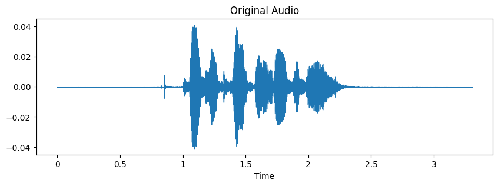

[interactive chart not shown]

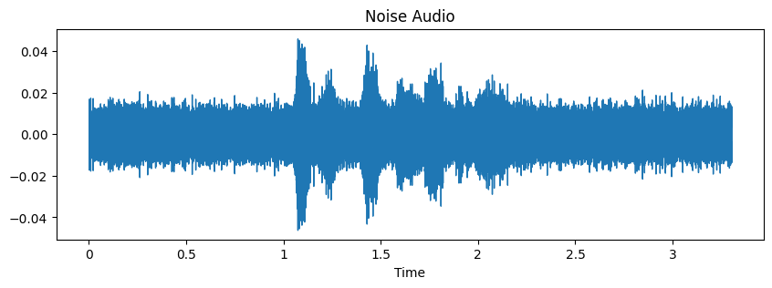

[interactive chart not shown]

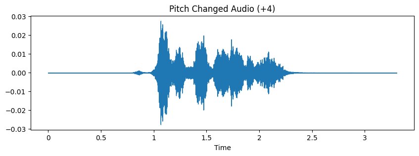

[interactive chart not shown]

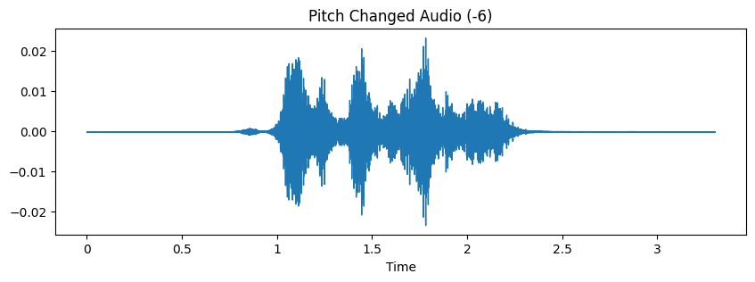

[interactive chart not shown]

```python
zip_file_path = 'Speech/Audio_Speech_Actors_01-24.zip'

with zipfile.ZipFile(zip_file_path, 'r') as zip_ref:
    for folder in zip_ref.infolist():
        file_name = folder.filename
        if file_name.endswith('.wav'):
            with zip_ref.open(folder) as audio_file:
                y, sr = librosa.load(audio_file)

                y_noise = add_noise(y)
                y_pitch1 = change_pitch(y, sr, 4)
                y_pitch2 = change_pitch(y, sr, -6)

                plt.figure(figsize=(10, 3))
                librosa.display.waveshow(y=y, sr=sr)
                plt.title('Original Audio')
                plt.show()
                display(Audio(data=y, rate=sr))

                plt.figure(figsize=(10, 3))
                librosa.display.waveshow(y=y_noise, sr=sr)
                plt.title('Noise Audio')
                plt.show()
                display(Audio(data=y_noise, rate=sr))

                plt.figure(figsize=(10, 3))
                librosa.display.waveshow(y=y_pitch1, sr=sr)
                plt.title('Pitch Changed Audio (+4)')
                plt.show()
                display(Audio(data=y_pitch1, rate=sr))

                plt.figure(figsize=(10, 3))
                librosa.display.waveshow(y=y_pitch2, sr=sr)
                plt.title('Pitch Changed Audio (-6)')
                plt.show()
                display(Audio(data=y_pitch2, rate=sr))

                break
```

#### When we extract features from the raw/transformed audio, they look something like this:

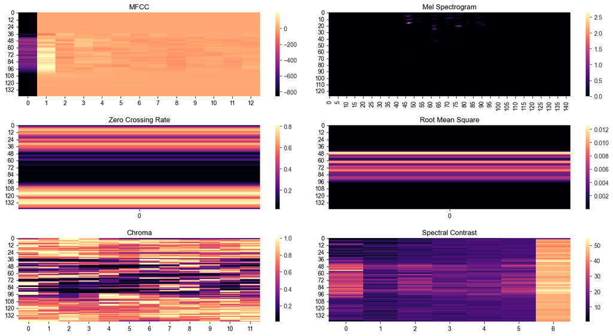

```python
mfccs = librosa.feature.mfcc(y=y, sr=sr, n_mfcc=13).T
mels = librosa.feature.melspectrogram(y=y, sr=sr, hop_length=512, n_mels=128)
zcr = librosa.feature.zero_crossing_rate(y, frame_length=2048, hop_length=512).T
rmse = librosa.feature.rms(y=y, frame_length=2048, hop_length=512).T
chroma = librosa.feature.chroma_stft(y=y, sr=sr, hop_length=512).T
spectral_contrast = librosa.feature.spectral_contrast(y=y, sr=sr, hop_length=512).T

fig, axes = plt.subplots(nrows=3, ncols=2, figsize=(15, 8))
sns.set_style("darkgrid")

sns.heatmap(mfccs, ax=axes[0, 0], cmap='magma')
sns.heatmap(mels, ax=axes[0, 1], cmap='magma')
sns.heatmap(zcr, ax=axes[1, 0], cmap='magma')
sns.heatmap(rmse, ax=axes[1, 1], cmap='magma')
sns.heatmap(chroma, ax=axes[2, 0], cmap='magma')
sns.heatmap(spectral_contrast, ax=axes[2, 1], cmap='magma')

axes[0, 0].set_title('MFCC')
axes[0, 1].set_title('Mel Spectrogram')
axes[1, 0].set_title('Zero Crossing Rate')
axes[1, 1].set_title('Root Mean Square')
axes[2, 0].set_title('Chroma')
axes[2, 1].set_title('Spectral Contrast')

plt.tight_layout()
plt.show()
```

#### Now we need to construct our B-Spline basis matrix. The visualization below shows what B-Splines look like and how the order of the polynomial affects the representation:

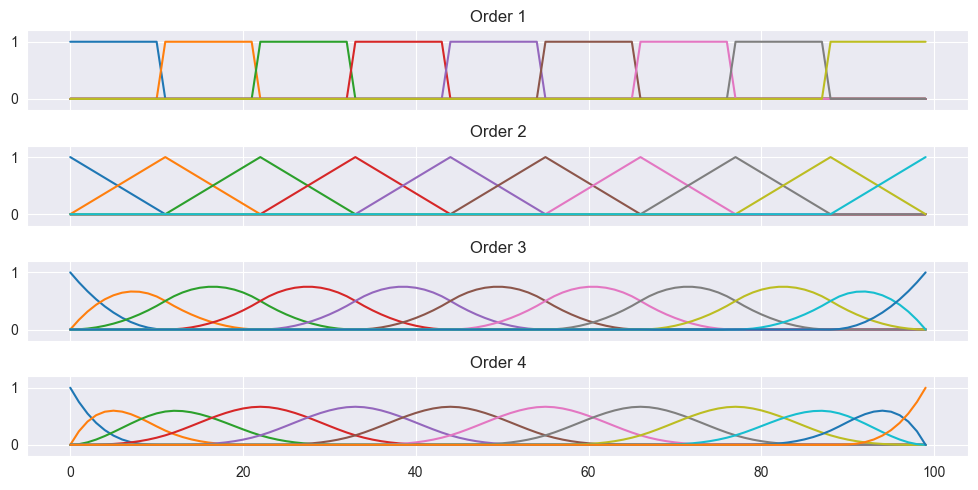

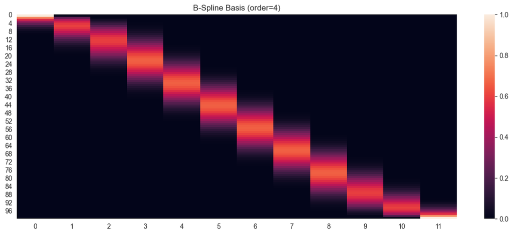

```python
n = 100
xx = np.arange(1, n+1)
nKnots = 10
knots = np.linspace(1, n, nKnots)

fig, axes = plt.subplots(nrows=4, sharex=True, figsize=(10,5))
for power in range(4):
    bs = BSplineBasis(knots=knots, order=power+1)
    bs_basis = bs(xx).T[0]
    axes[power].plot(bs_basis)
    axes[power].set_ylim((-0.2, 1.2))
    axes[power].set_title(f'Order {power+1}')
plt.tight_layout()
plt.show()

plt.figure(figsize=(12,5))
sns.heatmap(bs_basis)
plt.title(f'B-Spline Basis (order={power+1})')
plt.tight_layout()
plt.show()
```

#### Now that we have our B-Spline basis matrix, we can project the features audio features onto the spline basis, which reduces the dimensionality as shown below:

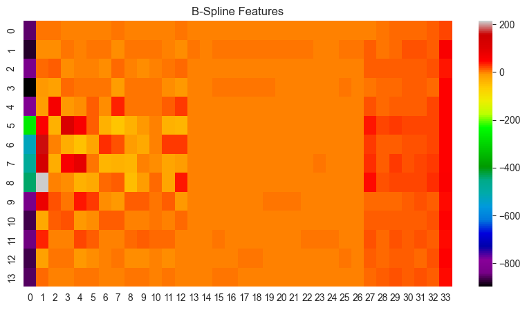

```python
features = np.concatenate((mfccs, zcr, rmse, chroma, spectral_contrast), axis=1)
m, n = features.shape

knots = np.linspace(0, 1, 12)
xx = np.linspace(0, 1, m)

bs = BSplineBasis(knots=knots, order=4)
bs_basis = bs(xx).T[0]

bs_features = lse_solver(bs_basis, features)

plt.figure(figsize=(10, 5))
sns.heatmap(bs_features, cmap='nipy_spectral')
plt.title('B-Spline Features')
plt.show()
```

### Implementing Feature Extraction and Saving Data

```python
def save_to_disk(variable, filename):
    np.save(filename, variable)
    del variable
    gc.collect()

def transform_features(y, sr):
    """Transform the audio signal and merge the data"""

    mfccs = librosa.feature.mfcc(y=y, sr=sr, n_mfcc=13).T
    mels = librosa.feature.melspectrogram(y=y, sr=sr, hop_length=512, n_mels=128)
    zcr = librosa.feature.zero_crossing_rate(y, frame_length=2048, hop_length=512).T
    rmse = librosa.feature.rms(y=y, frame_length=2048, hop_length=512).T
    chroma = librosa.feature.chroma_stft(y=y, sr=sr, hop_length=512).T
    spectral_contrast = librosa.feature.spectral_contrast(y=y, sr=sr, hop_length=512).T

    features = np.concatenate((mfccs, zcr, rmse, chroma, spectral_contrast), axis=1)

    del mfccs
    del mels
    del zcr
    del rmse
    del chroma
    del spectral_contrast
    gc.collect()

    return features

def extract_features(y, sr, nknots=10, order=4):
    """Extract features from the audio signal using B-Splines"""

    features = transform_features(y, sr)
    m, n = features.shape

    knots = np.linspace(0, 1, nknots)
    xx = np.linspace(0, 1, m)

    bs = BSplineBasis(knots=knots, order=order)
    bs_basis = bs(xx).T[0]

    bs_features = lse_solver(bs_basis, features)

    del bs
    del bs_basis
    del features
    gc.collect()

    return bs_features
```

```python
nknots = 12
Audio_data = np.zeros((60*24, nknots+2, 34*8), dtype=np.float32)

inds = np.zeros((60*24, 7), dtype=np.uint8)
i = 0
with zipfile.ZipFile(zip_file_path, 'r') as zip_ref:
    for folder in tqdm(zip_ref.infolist()):
        file_name = folder.filename
        if file_name.endswith('.wav'):
            with zip_ref.open(folder) as audio_file:
                idx = np.array(file_name.split('/')[1][:-4].split('-')).astype(np.uint8)
                inds[i, :] = idx

                y, sr = librosa.load(audio_file)

                y_noise = add_noise(y)
                y_pitch1 = change_pitch(y, sr, 4)
                y_pitch2 = change_pitch(y, sr, -6)
                y_pitch3 = change_pitch(y, sr, 3)
                y_speed1 = change_speed(y, 1.5)
                y_speed2 = change_speed(y, 2.0)
                y_speed3 = change_speed(y, 0.8)
                y_speed4 = change_speed(y, 0.5)

                features1 = extract_features(y_noise, sr, nknots, 4)
                features2 = extract_features(y_pitch1, sr, nknots, 4)
                features3 = extract_features(y_pitch2, sr, nknots, 4)
                features4 = extract_features(y_pitch3, sr, nknots, 4)
                features5 = extract_features(y_speed1, sr, nknots, 4)
                features6 = extract_features(y_speed2, sr, nknots, 4)
                features7 = extract_features(y_speed3, sr, nknots, 4)
                features8 = extract_features(y_speed4, sr, nknots, 4)

                features = np.concatenate((features1, features2, features3, features4, features5, features6, features7, features8), axis=1)
                m, n = features.shape

                Audio_data[i, ...] = features

                del features, features1, features2, features3, features4, \
                    features5, features6, features7, features8, y_noise, y_pitch1, y_pitch2, y_pitch3, \
                    y_speed1, y_speed2, y_speed3, y_speed4, y, sr

                gc.collect()

                i += 1
```

```python
id_combined = np.concatenate((id_train, id_test), axis=0)

inds_id = inds[:, 1:]
id_combined = id_combined[:, -6:]

Audio_sorted = np.zeros_like(Audio_data, dtype=np.float32)
inds_sorted = np.zeros_like(inds_id, dtype=np.uint8)
for i in range(id_combined.shape[0]):
    target_row = id_combined[i]
    mask = np.all(inds_id == target_row, axis=1)
    index = np.nonzero(mask)[0].item()
    Audio_sorted[i, :] = Audio_data[index, :]
    inds_sorted[i, :] = inds_id[index, :]

Audio_train = Audio_sorted[:len(id_train)]
Audio_test = Audio_sorted[len(id_train):]

del Audio_data
del Audio_sorted
del inds
del inds_id
del inds_sorted
gc.collect()

print(Audio_train.shape)
print(Audio_test.shape)
```

```
(960, 14, 272)
(480, 14, 272)
```

```python
audio_data_dir = os.path.join(os.getcwd(), 'Audio_Data')
os.makedirs(audio_data_dir, exist_ok=True)

save_to_disk(Audio_train, os.path.join(audio_data_dir, 'Audio_train.npy'))
save_to_disk(Audio_test, os.path.join(audio_data_dir, 'Audio_test.npy'))
```

### References:

[1] Hastie, T., Tibshirani, R., Friedman, J. (2009). Basis Expansions and Regularization. In: The Elements of Statistical Learning. Springer Series in Statistics. Springer, New York, NY. https://doi.org/10.1007/978-0-387-84858-7_5